# House Price Analysis

# 4. Prediksi Model

```r
# prediksi dengan model pertama
library(MLmetrics)
pred1 <- predict(admission_m, admission)

RMSE(y_pred = pred1, y_true = admission$Chance.of.Admit)
```

```
## [1] 0.0693927
```

```r
# prediksi dengan model stepwise
pred2 <- predict(model_back, admission)

RMSE(y_pred = pred2, y_true = admission$Chance.of.Admit)
```

```
## [1] 0.06326207
```

```r
range(admission$Chance.of.Admit)
```

```
## [1] 0.34 0.97
```

Dilihat dari nilai RMSE dari kedua model masih cukup baik

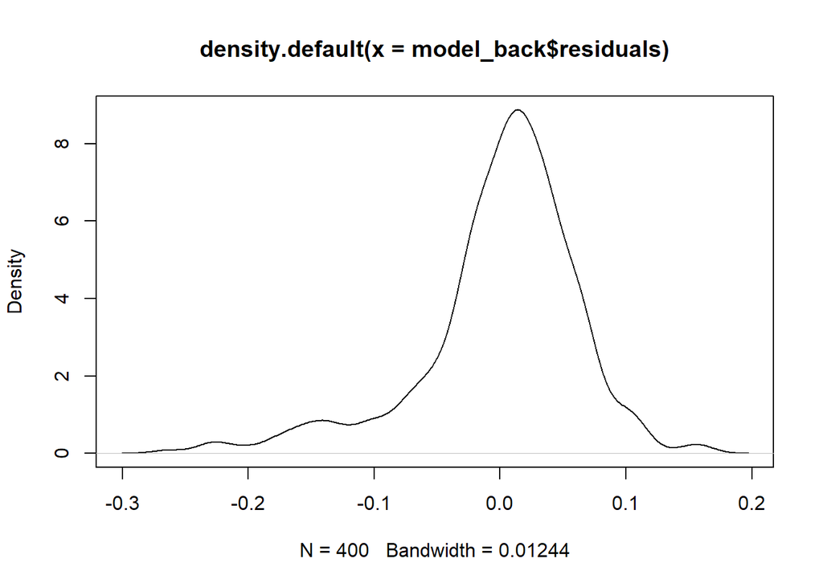

```r
plot(density(model_back$residuals))
```

```r
library(stats)
shapiro.test(admission_m$residuals)
```

```
##
##  Shapiro-Wilk normality test
##
## data:  admission_m$residuals
## W = 0.94782, p-value = 1.143e-10
```

```r
library(lmtest)
bptest(admission_m)
```

```
##
##  studentized Breusch-Pagan test
##
## data:  admission_m
## BP = 19.562, df = 1, p-value = 9.737e-06
```

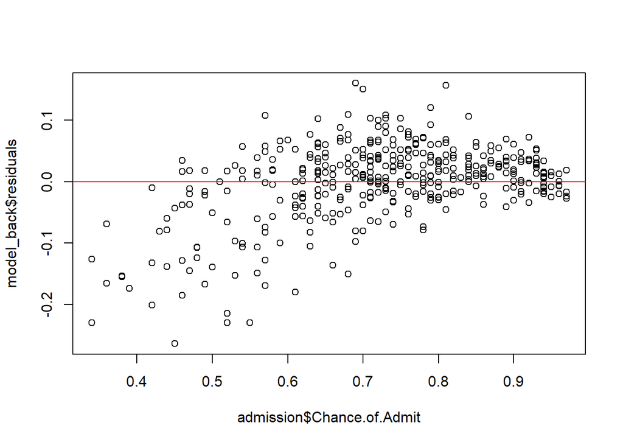

```r
plot(admission$Chance.of.Admit, model_back$residuals)
abline(h = 0, col = "red")
```

```r
library(car)
## Loading required package: carData
vif(model_back)
```

```
##   GRE.Score TOEFL.Score         LOR        CGPA    Research
##    4.585053    4.104255    1.829491    4.808767    1.530007
```

Tidak ada nilai sama dengan atau lebih dari 10 sehingga tidak ditemukan Multicollinearity antar variabel (antar variabel prediktor saling independen).

# Kesimpulan

Model `model_back` Memiliki Adj R-Square 0.8 yang baik

Artinya, Nilai `GRE.Score`, `TOEFL.Score`, `CGPA`, `LOR`, `Research` naik maka nilai `Chance.of.Admit` akan ikut naik, dengan kata lain jika ingin memliki Peluang yang tinggi maka harus meningkatkan nilai nilai tersebut, dan setiap nilai prediktor lainnya akan ikut mempengaruhi satu sama lain